# E-Level Technical Exercise Part I

Jingyu Gao

2/18/2018

### Introduction

This document analyses the global trend of **access to sanitation facilities** data provided by the World Development Indicators database using data from 1990 to 2015. It answers three primary questions:

- How is access to sanitation facilities changing over time?
- Is there an overall trend?
- Does it vary by [income group](https://datahelpdesk.worldbank.org/knowledgebase/articles/906519-world-bank-country-and-lending-groups)?

Access to sanitation facilities is [defined](https://data.worldbank.org/indicator/SH.STA.ACSN) as **the percentage of the population using improved sanitation facilities**. Improved sanitation facilities are likely to ensure hygienic separation of human excreta from human contact. They include flush/pour flush (to piped sewer system, septic tank, pit latrine), ventilated improved pit (VIP) latrine, pit latrine with slab, and composting toilet.

### Global Trend 1990-2015

Over the period 1990-2015, access to sanitation facilities has been improved steadily, but the level of progress is heterogeneous around the world. East Asia and Pacific (EAP) witnessed the biggest success: over 74.89 percent of its population are now using improved sanitation facilities, substantially increasing from 47.53 percent in 1990. Since 2001, EAP has greater access to sanitation facilities than the world average. At the same time, developing countries in South Asia (SA) and Sub-Sahara Africa (SSA) still are lagging behind the rest of the world, despite significant improvement in SA. Condition in SSA has barely changed: 29.79 percent of people there have access to improved sanitation facilities in 2015, only slightly higher than what it was in 1990 (23.78 percent).

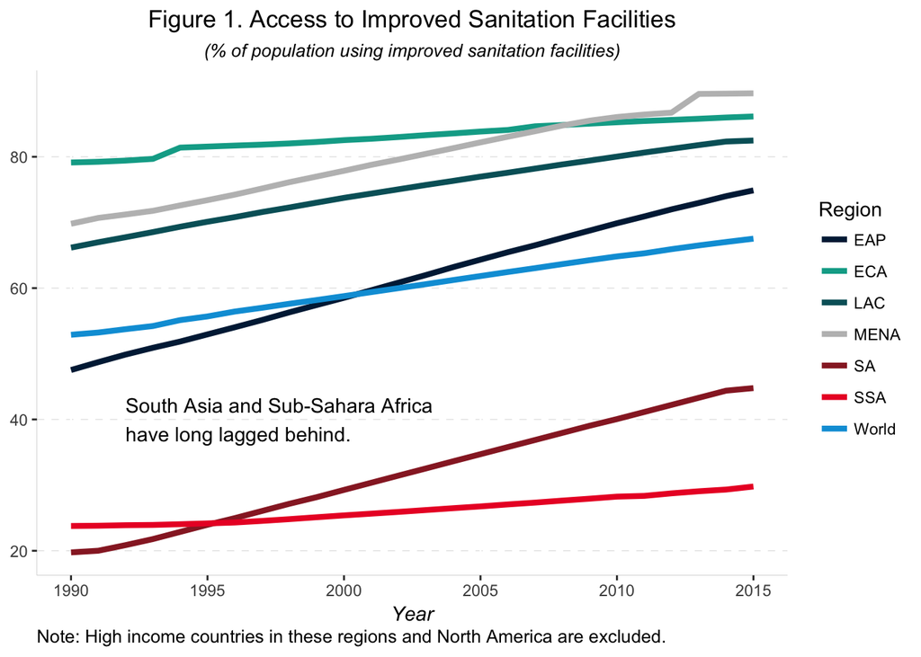

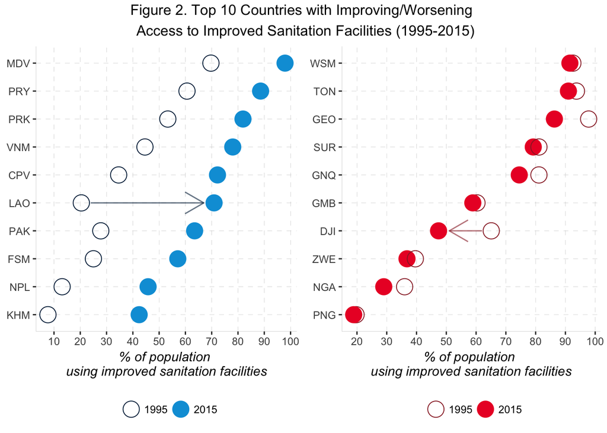

### Better Income, Better Sanitation

As indicated in Figure 3, better income is associated with greater access to facilities that ensure hygienic seperation of human excreta. Almost everyone (over 90 percent of population) living in high income countries have access to such improved sanitation facilities, while in low income countries fewer than half of their population do so. A comparison between 1990 and 2015 also illustrates the fact that when countries become richer, more of their citizens would use improved sanitation facilities, as shown by the colored spots that shifted up- and right-ward in 2015 compared to 1990.

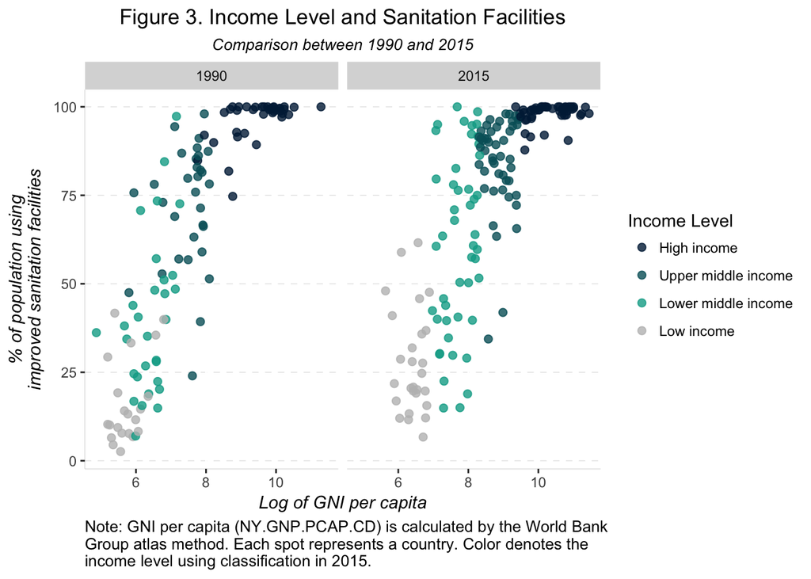